# 머신러닝으로 디폴트 찾기

#### Dataset : 2005년 10월 대만 은행 자료

- 그 당시 점점 더 많은 은행들이 고객들에게 상환 능력에 관계없이 현금 신용을 공여하고 있었기 때문에 점점 더 많은 사람들이 상당한 양의 부채를 축적해 디폴트를 초래했다. 이 연구의 목표는 과거 상환 내역과 함께 고객에 대한 몇가지 기본정보를 사용해 디폴트 가능성이 높은 사람을 예측하는 것이다. 이전 6개월(2005년 4~9월)의 상환 내역을 사용해 고객이 2005년 10월에 디폴트를 할지 여부를 예측하려고 한다.

###### 변수에 대한 설명

- limit_bal: 대출 총액(대만 달러)
- sex: 성별
- education: 학력
- marriage: 결혼 상태
- age: 나이
- payment*status*{month}: 이전 6개의 상환 현황
- bill*statusment*{month}: 이전 6개의 청구 금액
- previous*payment*{month}: 이전 6개월에서 직전 월 상환 현황

### 데이터로드 및 데이터 유형 관리

```python
import pandas as pd
```

```python
# 이 방법은 큰 텍스트 파일을 열지 않고도 처리할 데이터 종류를 확인할 수 있다. (리눅스 명령어)
!head -n 5 credit_card_default.csv
```

[output not shown]

```python
# 데이터를 로드한다.
df = pd.read_csv('credit_card_default.csv', index_col=0, na_values='')
```

```python
df.head(5)
```

|  | limit_bal | sex | education | marriage | age | payment_status_sep | payment_status_aug | payment_status_jul | payment_status_jun | payment_status_may | ... | bill_statement_jun | bill_statement_may | bill_statement_apr | previous_payment_sep | previous_payment_aug | previous_payment_jul | previous_payment_jun | previous_payment_may | previous_payment_apr | default_payment_next_month |
| --- | --- | --- | --- | --- | --- | --- | --- | --- | --- | --- | --- | --- | --- | --- | --- | --- | --- | --- | --- | --- | --- |
| 0 | 20000 | Female | University | Married | 24.0 | Payment delayed 2 months | Payment delayed 2 months | Payed duly | Payed duly | Unknown | ... | 0 | 0 | 0 | 0 | 689 | 0 | 0 | 0 | 0 | 1 |
| 1 | 120000 | Female | University | Single | 26.0 | Payed duly | Payment delayed 2 months | Unknown | Unknown | Unknown | ... | 3272 | 3455 | 3261 | 0 | 1000 | 1000 | 1000 | 0 | 2000 | 1 |
| 2 | 90000 | Female | University | Single | 34.0 | Unknown | Unknown | Unknown | Unknown | Unknown | ... | 14331 | 14948 | 15549 | 1518 | 1500 | 1000 | 1000 | 1000 | 5000 | 0 |
| 3 | 50000 | Female | University | Married | 37.0 | Unknown | Unknown | Unknown | Unknown | Unknown | ... | 28314 | 28959 | 29547 | 2000 | 2019 | 1200 | 1100 | 1069 | 1000 | 0 |
| 4 | 50000 | Male | University | Married | 57.0 | Payed duly | Unknown | Payed duly | Unknown | Unknown | ... | 20940 | 19146 | 19131 | 2000 | 36681 | 10000 | 9000 | 689 | 679 | 0 |

5 rows × 24 columns

```python
# 타깃을 분리한다.
X = df.copy()
y = X.pop('default_payment_next_month')
```

##### 추가 사항

- 큰 테이블을 쉽게 사용하기 위해 더 나은 메모리 할당을 할 수 있다.

```python
# 데이터 유형 확인
df.dtypes
```

```
limit_bal                       int64
sex                            object
education                      object
marriage                       object
age                           float64
payment_status_sep             object
payment_status_aug             object
payment_status_jul             object
payment_status_jun             object
payment_status_may             object
payment_status_apr             object
bill_statement_sep              int64
bill_statement_aug              int64
bill_statement_jul              int64
bill_statement_jun              int64
bill_statement_may              int64
bill_statement_apr              int64
previous_payment_sep            int64
previous_payment_aug            int64
previous_payment_jul            int64
previous_payment_jun            int64
previous_payment_may            int64
previous_payment_apr            int64
default_payment_next_month      int64
dtype: object
```

```python
# DataFrame이 실제로 얼마나 메모리를 사용하는지 확인하는 함수
def get_df_memory_usage(df, top_columns=5):
    print('Memory usage----')
    memory_per_column = df.memory_usage(deep=True) / 1024 ** 2
    print(f'Top {top_columns} columns by memory (MB):')
    print(memory_per_column.sort_values(ascending=False).head(top_columns))
    print(f'Total size: {memory_per_column.sum():.4f} MB')
```

```python
get_df_memory_usage(df)
```

```
Memory usage----
Top 5 columns by memory (MB):
education             1.965001
payment_status_sep    1.954342
payment_status_aug    1.920288
payment_status_jul    1.916343
payment_status_jun    1.904229
dtype: float64
Total size: 20.7012 MB
```

```python
# object 열을 category형으로 변환
df_cat = df.copy()
object_columns = df_cat.select_dtypes(include='object').columns
df_cat[object_columns] = df_cat[object_columns].astype('category')
```

```python
get_df_memory_usage(df_cat)
```

```
Memory usage----
Top 5 columns by memory (MB):
Index                   0.228882
bill_statement_aug      0.228882
previous_payment_apr    0.228882
previous_payment_may    0.228882
previous_payment_jun    0.228882
dtype: float64
Total size: 3.9265 MB
```

DataFrame의 크기를 80% 정도 줄였다. 또한 정수형(int64)을 더 작은 메모리 단위(int8)로 하향할 수 있지만, 열의 최솟값과 최댓값을 확인 후 그대로 두기로 했다.

### 탐색적 데이터 분석(EDA)

- 어떤 종류의 데이터를 갖고 있는가?
- 변수의 분포는?
  1. 이상값이 있는가?
  2. 변환이 필요한가? 어떤 모델은 정규 분포 변수와 더 잘 작동하거나 필요하므로 로그 변환을 사용할 수 있다.
  3. 분포는 그룹마다 다른가?
- 누락된 데이터가 있는가?
- 일부 변수 간에 선형 관계가 있는가?
- 기존 변수 집합을 사용해 새 파생변수를 생성할 수 있는가?
- 분석과 관련이 없는 변수 제거

#### 일변량 분석

```python
import pandas as pd
import seaborn as sns
import numpy as np
```

```python
# 수치형 변수에 대한 요약 통계량
df.describe().transpose().round(2)
```

|  | count | mean | std | min | 25% | 50% | 75% | max |
| --- | --- | --- | --- | --- | --- | --- | --- | --- |
| limit_bal | 30000.0 | 167484.32 | 129747.66 | 10000.0 | 50000.00 | 140000.0 | 240000.00 | 1000000.0 |
| age | 29850.0 | 35.49 | 9.22 | 21.0 | 28.00 | 34.0 | 41.00 | 79.0 |
| bill_statement_sep | 30000.0 | 51223.33 | 73635.86 | -165580.0 | 3558.75 | 22381.5 | 67091.00 | 964511.0 |
| bill_statement_aug | 30000.0 | 49179.08 | 71173.77 | -69777.0 | 2984.75 | 21200.0 | 64006.25 | 983931.0 |
| bill_statement_jul | 30000.0 | 47013.15 | 69349.39 | -157264.0 | 2666.25 | 20088.5 | 60164.75 | 1664089.0 |
| bill_statement_jun | 30000.0 | 43262.95 | 64332.86 | -170000.0 | 2326.75 | 19052.0 | 54506.00 | 891586.0 |
| bill_statement_may | 30000.0 | 40311.40 | 60797.16 | -81334.0 | 1763.00 | 18104.5 | 50190.50 | 927171.0 |
| bill_statement_apr | 30000.0 | 38871.76 | 59554.11 | -339603.0 | 1256.00 | 17071.0 | 49198.25 | 961664.0 |
| previous_payment_sep | 30000.0 | 5663.58 | 16563.28 | 0.0 | 1000.00 | 2100.0 | 5006.00 | 873552.0 |
| previous_payment_aug | 30000.0 | 5921.16 | 23040.87 | 0.0 | 833.00 | 2009.0 | 5000.00 | 1684259.0 |
| previous_payment_jul | 30000.0 | 5225.68 | 17606.96 | 0.0 | 390.00 | 1800.0 | 4505.00 | 896040.0 |
| previous_payment_jun | 30000.0 | 4826.08 | 15666.16 | 0.0 | 296.00 | 1500.0 | 4013.25 | 621000.0 |
| previous_payment_may | 30000.0 | 4799.39 | 15278.31 | 0.0 | 252.50 | 1500.0 | 4031.50 | 426529.0 |
| previous_payment_apr | 30000.0 | 5215.50 | 17777.47 | 0.0 | 117.75 | 1500.0 | 4000.00 | 528666.0 |
| default_payment_next_month | 30000.0 | 0.22 | 0.42 | 0.0 | 0.00 | 0.0 | 0.00 | 1.0 |

```python
# 범주형 변수에 대한 요약 통계량
df.describe(include='object').transpose()
```

|  | count | unique | top | freq |
| --- | --- | --- | --- | --- |
| sex | 29850 | 2 | Female | 18027 |
| education | 29850 | 4 | University | 13960 |
| marriage | 29850 | 3 | Single | 15891 |
| payment_status_sep | 30000 | 10 | Unknown | 17496 |
| payment_status_aug | 30000 | 10 | Unknown | 19512 |
| payment_status_jul | 30000 | 10 | Unknown | 19849 |
| payment_status_jun | 30000 | 10 | Unknown | 20803 |
| payment_status_may | 30000 | 9 | Unknown | 21493 |
| payment_status_apr | 30000 | 9 | Unknown | 21181 |

[output not shown]

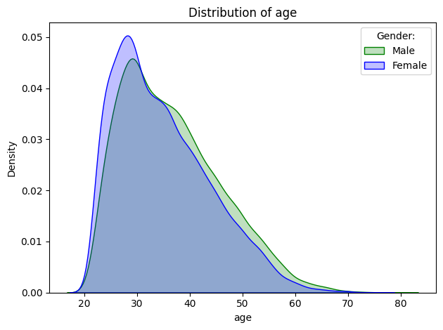

```python
import plotly.express as px
import plotly.io as pio
import matplotlib.pyplot as plt

fig, ax = plt.subplots()
sns.distplot(df.loc[df.sex =='Male', 'age'].dropna(),
            hist=False, color='green',
            kde_kws = {"shade": True},
            ax=ax, label='Male')
sns.distplot(df.loc[df.sex == 'Female', 'age'].dropna(),
            hist=False, color='blue',
            kde_kws={"shade": True},
            ax=ax, label='Female')
ax.set_title('Distribution of age')
ax.legend(title='Gender:')

plt.tight_layout()
plt.show()
```

초록색은 남성의 분포, 파란색은 여성의 분포로 성별 분포의 모양에 큰 차이가 없다는 것을 알 수 있다. 여성이 평균적으로 약간 더 젊다.

#### 다변량 분석

[output not shown]

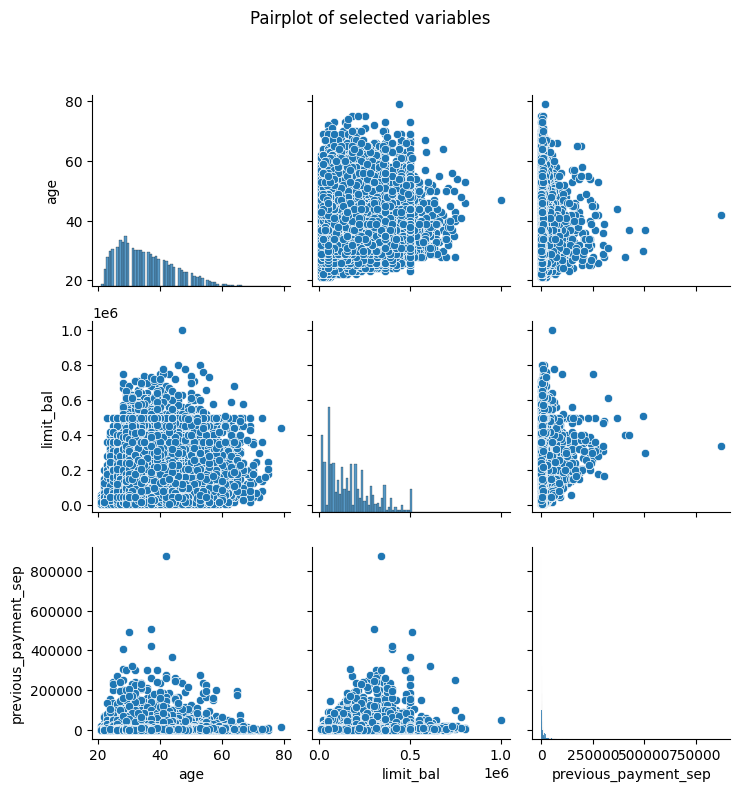

```python
pair_plot = sns.pairplot(df[['age', 'limit_bal', 'previous_payment_sep']])
pair_plot.fig.suptitle('Pairplot of selected variables', y=1.05)

plt.tight_layout()
plt.show()
```

pair-plot의 대각선은 일변량 히스토그램을 나타내고, 비대각은 두 특징의 산점도를 나타낸다.

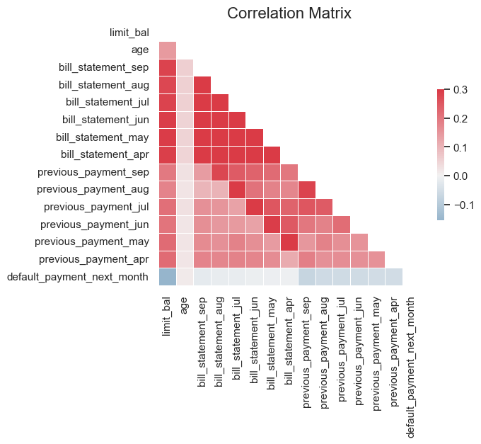

```python
# 상관관계 히트맵을 그리는 함수
def plot_correlation_matrix(corr_mat):
    sns.set(style="white")
    mask = np.zeros_like(corr_mat, dtype=bool)
    mask[np.triu_indices_from(mask)] = True
    fig, ax = plt.subplots()
    cmap = sns.diverging_palette(240, 10, n=9, as_cmap=True)
    sns.heatmap(corr_mat, mask=mask, cmap=cmap, vmax=.3, center=0,
               square=True, linewidths=.5,
               cbar_kws={"shrink": .5}, ax=ax)
    ax.set_title('Correlation Matrix', fontsize=16)
    sns.set(style="darkgrid")

corr_mat = df.select_dtypes(include='number').corr()
plot_correlation_matrix(corr_mat)
```

그림을 보면 나이는 다른 특징들과 관련이 적다.

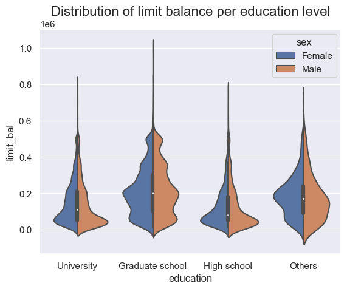

```python
ax = sns.violinplot(x='education', y='limit_bal', hue='sex', split=True, data=df)
ax.set_title('Distribution of limit balance per education level', fontsize=16)
```

그림을 분석하면

- 대학원의 교육수준을 가진 그룹에서 가장 큰 잔고가 나타난다.
- 분포 형태는 교육 수준에 따라 다르다. 대학원 졸업은 기타 범주와 비슷하고 고등학교 졸업은 대학 졸업과 비슷하다.
- 성별 차이는 거의 없다.

*바이올린 그래프*

- 바이올린 중심에 검은색 막대로 표시되는 사분위수 범위가 나타난다.
- 흰색 점은 중앙값이다.

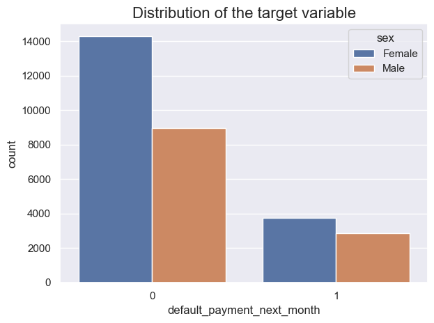

```python
ax = sns.countplot(x='default_payment_next_month', data=df, hue='sex', orient='h')
ax.set_title('Distribution of the target variable', fontsize=16)

plt.tight_layout()
# plt.savefig('images/ch8_im9.png')
plt.show()
```

그래프를 분석하면 남성 고객의 디폴트 비율이 더 높다.

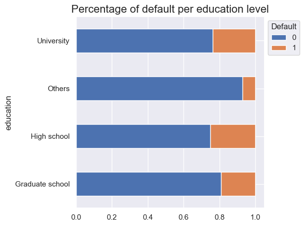

```python
ax = df.groupby('education')['default_payment_next_month'] \
       .value_counts(normalize=True) \
       .unstack() \
       .plot(kind='barh', stacked='True')
ax.set_title('Percentage of default per education level',
             fontsize=16)
ax.legend(title='Default', bbox_to_anchor=(1,1))

plt.tight_layout()
plt.show()
```

교육 수준별로 보면 디폴트는 상대적으로 고졸 고객들에서 많이 발생한다.

##### 추가 사항

자동 EDA 리포트 생성

```python
import pandas_profiling
```

```python
# df.profile_report()
```

### 훈련 및 테스트 집합으로 데이터 분할

결측값이 있을 때 일반적으로 평균으로 결측값을 대치한다. 데이터를 분할하기 전에 이 작업을 수행했다면 테스트 집합의 데이터를 사용해 평균을 계산하기 때문에 데이터 유출을 초래한다. 따라서 데이터를 훈련과 테스트 집합으로 분할한 후 훈련 집합에서 관찰된 데이터를 사용해 훈련을 수행해야 한다.

```python
from sklearn.model_selection import train_test_split
```

```python
# 데이터를 층화시키고 훈련과 테스트 집합으로 분할
X_train, X_test, y_train, y_test = train_test_split(X, y, test_size=0.2, stratify=y, random_state=42)
```

```python
y_train.value_counts(normalize=True)
# y_test.value_counts(normalize=True)
```

```
default_payment_next_month
0    0.778792
1    0.221208
Name: proportion, dtype: float64
```

```python
# 훈련-검증-테스트 분할
# VALID_SIZE = 0.1
# TEST_SIZE = 0.2

# X_train, X_temp, y_train, y_temp = train_test_split(X, y,
#                                                    test_size=(VALID_SIZE + TEST_SIZE), stratify=y, random_state=42)
# NEW_TEST_SIZE = np.around(TEST_SIZE / (VALID_SIZE + TEST_SIZE), 2)

# X_valid, X_test, y_valid, y_test = train_test_split(X_temp, y_temp,
#                                                    test_size=NEW_TEST_SIZE, stratify=y_temp, random_state=42)

# 일반적으로 교차 검증 사용
```

### 결측값 처리

결측값을 발생 원인별로 분류하면

- 랜덤으로 완전 누락(MCAR): 누락된 원인이 나머지 데이터와 관련 없음
- 랜덤 결측(MAR): 다른 열의 데이터들로 누락된 데이터를 유추할 수 있음
- 임의가 아닌 결측(MNAR): 결측값에 대한 근본적인 원인이 있는 경우
- 구조적으로 누락된 데이터: 논리적인 이유로 데이터 누락

```python
import pandas as pd
import missingno
from sklearn.impute import SimpleImputer
```

```python
X.info()
```

```
<class 'pandas.core.frame.DataFrame'>
Index: 30000 entries, 0 to 29999
Data columns (total 23 columns):
 #   Column                Non-Null Count  Dtype
---  ------                --------------  -----
 0   limit_bal             30000 non-null  int64
 1   sex                   29850 non-null  object
 2   education             29850 non-null  object
 3   marriage              29850 non-null  object
 4   age                   29850 non-null  float64
 5   payment_status_sep    30000 non-null  object
 6   payment_status_aug    30000 non-null  object
 7   payment_status_jul    30000 non-null  object
 8   payment_status_jun    30000 non-null  object
 9   payment_status_may    30000 non-null  object
 10  payment_status_apr    30000 non-null  object
 11  bill_statement_sep    30000 non-null  int64
 12  bill_statement_aug    30000 non-null  int64
 13  bill_statement_jul    30000 non-null  int64
 14  bill_statement_jun    30000 non-null  int64
 15  bill_statement_may    30000 non-null  int64
 16  bill_statement_apr    30000 non-null  int64
 17  previous_payment_sep  30000 non-null  int64
 18  previous_payment_aug  30000 non-null  int64
 19  previous_payment_jul  30000 non-null  int64
 20  previous_payment_jun  30000 non-null  int64
 21  previous_payment_may  30000 non-null  int64
 22  previous_payment_apr  30000 non-null  int64
dtypes: float64(1), int64(13), object(9)
memory usage: 5.5+ MB
```

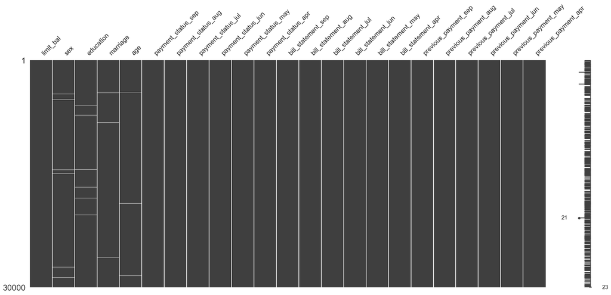

```python
# DataFrame의 빈 값을 시각화
missingno.matrix(X)
```

```python
# 데이터 유형별 결측값이 있는 열 정의
NUM_FEATURES = ['age']
CAT_FEATURES = ['sex', 'education', 'marriage']
```

```python
# 수치 특징을 중앙값으로 대치한다.
for col in NUM_FEATURES:
    num_imputer = SimpleImputer(strategy='median')
    num_imputer.fit(X_train[[col]])
    X_train.loc[:, col] = num_imputer.transform(X_train[[col]])
    X_test.loc[:, col] = num_imputer.transform(X_test[[col]])
```

```python
# 범주 특징을 최빈값으로 대치한다
for col in CAT_FEATURES:
    cat_imputer = SimpleImputer(strategy='most_frequent')
    cat_imputer.fit(X_train[[col]])
    X_train.loc[:, col] = cat_imputer.transform(X_train[[col]])
    X_test.loc[:, col] = cat_imputer.transform(X_test[[col]])
```

```python
X_train.info()
```

```
<class 'pandas.core.frame.DataFrame'>
Index: 24000 entries, 22788 to 27126
Data columns (total 23 columns):
 #   Column                Non-Null Count  Dtype
---  ------                --------------  -----
 0   limit_bal             24000 non-null  int64
 1   sex                   24000 non-null  object
 2   education             24000 non-null  object
 3   marriage              24000 non-null  object
 4   age                   24000 non-null  float64
 5   payment_status_sep    24000 non-null  object
 6   payment_status_aug    24000 non-null  object
 7   payment_status_jul    24000 non-null  object
 8   payment_status_jun    24000 non-null  object
 9   payment_status_may    24000 non-null  object
 10  payment_status_apr    24000 non-null  object
 11  bill_statement_sep    24000 non-null  int64
 12  bill_statement_aug    24000 non-null  int64
 13  bill_statement_jul    24000 non-null  int64
 14  bill_statement_jun    24000 non-null  int64
 15  bill_statement_may    24000 non-null  int64
 16  bill_statement_apr    24000 non-null  int64
 17  previous_payment_sep  24000 non-null  int64
 18  previous_payment_aug  24000 non-null  int64
 19  previous_payment_jul  24000 non-null  int64
 20  previous_payment_jun  24000 non-null  int64
 21  previous_payment_may  24000 non-null  int64
 22  previous_payment_apr  24000 non-null  int64
dtypes: float64(1), int64(13), object(9)
memory usage: 4.4+ MB
```

```python
X_train.isnull().sum()
```

```
limit_bal               0
sex                     0
education               0
marriage                0
age                     0
payment_status_sep      0
payment_status_aug      0
payment_status_jul      0
payment_status_jun      0
payment_status_may      0
payment_status_apr      0
bill_statement_sep      0
bill_statement_aug      0
bill_statement_jul      0
bill_statement_jun      0
bill_statement_may      0
bill_statement_apr      0
previous_payment_sep    0
previous_payment_aug    0
previous_payment_jul    0
previous_payment_jun    0
previous_payment_may    0
previous_payment_apr    0
dtype: int64
```

### 범주형 변수 인코딩

##### 레이블 인코딩

- 레이블 인코딩은 관계를 생성한다. 범주가 국가인 경우에는 사용할 수 없고, 나쁨-중간-좋은 같은 척도로 서비스 등급과 같은 일종의 순서를 나타내는 특징에는 사용할 수 있다.

##### 원-핫 인코딩

- 단점은 데이터셋의 차원이 크게 증가하며 더미 변수 트랩이 발생하기 때문에 하나의 열을 제거하는 것이 좋다.

```python
import pandas as pd
from sklearn.preprocessing import LabelEncoder, OneHotEncoder
from sklearn.compose import ColumnTransformer
```

```python
# COL = 'education'

# X_train_copy = X_train.copy()
# X_test_copy = X_test.copy()

# label_enc = LabelEncoder()
# label_enc.fit(X_train_copy[COL])
# X_train_copy.loc[:, COL] = label_enc.transform(X_train_copy[COL])
# X_test_copy.loc[:, COL] = label_enc.transform(X_test_copy[COL])
```

```python
# 원-핫 인코딩할 범주형을 선택
CAT_FEATURES = X_train.select_dtypes(include='object').columns.to_list()
```

```python
one_hot_encoder = OneHotEncoder(sparse=False, handle_unknown='error', drop='first')
```

```python
# 원-핫 인코더를 사용해 열 변환기를 생성한다.
one_hot_transformer = ColumnTransformer(
    [("one_hot", one_hot_encoder, CAT_FEATURES)]
)

# 원-핫 인코딩에 pandas.get_dummies 사용
# X_train = pd.get_dummies(X_train, prefix_sep='_', drop_first=True)

# # OneHotEncoder에 가능한 범주 지정
# one_hot_encoder = OneHotEncoder(
#     categories = [['Male', 'Female', 'Unknown']],
#     sparse = False,
#     handle_unknown = 'error',
#     drop = 'first'
# )

# one_hot_transformer = ColumnTransformer(
#     [("one_hot", one_hot_encoder, ['sex'])]
# )

# one_hot_transformer.fit(X_train)

# one_hot_transformer.get_feature_names_out()
```

```python
one_hot_transformer.fit(X_train)
```

```
ColumnTransformer(transformers=[('one_hot',
                                 OneHotEncoder(drop='first', sparse=False),
                                 ['sex', 'education', 'marriage',
                                  'payment_status_sep', 'payment_status_aug',
                                  'payment_status_jul', 'payment_status_jun',
                                  'payment_status_may',
                                  'payment_status_apr'])])
```

```python
#변환기를 훈련과 테스트 집합 모두에 적용
col_names = one_hot_transformer.get_feature_names_out()

X_train_cat = pd.DataFrame(one_hot_transformer.transform(X_train),
                           columns = col_names,
                           index=X_train.index)
X_train_ohe = pd.concat([X_train, X_train_cat], axis=1).drop(CAT_FEATURES, axis=1)

X_test_cat = pd.DataFrame(one_hot_transformer.transform(X_test),
                         columns = col_names,
                         index=X_test.index)
X_test_ohe = pd.concat([X_test, X_test_cat], axis=1).drop(CAT_FEATURES, axis=1)
```

```python
# # Category Encoders 라이브러리
# import category_encoders as ce

# one_hot_encoder_ce = ce.OneHotEncoder(use_cat_names=True)

# one_hot_encoder_ce.fit(X_train)
# X_train_ce = one_hot_encoder_ce.transform(X_train)

# # 타깃 인코딩
# target_encoder = ce.TargetEncoder(smoothing=0)
# target_encoder.fit(X_train.sex, y_train)
# target_encoder.transform(X_train.sex).head()
```

### 의사결정 트리 분류기 적합화

#### 결정 트리의 장점은

- 트리 형태로 쉽게 시각화할 수 있다. - 높은 해석력
- 훈련이 빠르고 단계를 예측할 수 있다.
- 튜닝할 초매개 변수가 적다.
- 수치와 범주 특징을 모두 지원한다.
- 비선형성 데이터를 처리한다.
- 특성의 크기 조정이나 정규화가 필요 없다.
- 비모수적 모델이다. - 특징/타깃 분포에 대한 가정이 없다.

#### 결정 트리의 단점은

- 불안정성: 트리는 입력 데이터의 노이즈에 매우 민감하다. 데이터가 조금만 변경되면 모델이 크게 바뀔 수 있다.
- 과적합: 최대값이나 정지 기준을 제공하지 않으면 나무는 매우 깊게 자라며 일반화되지 않는다.

```python
from sklearn.tree import DecisionTreeClassifier, export_graphviz
from sklearn import metrics
from io import StringIO
import seaborn as sns
from ipywidgets import Image
import pydotplus
```

```python
from sklearn import metrics
import matplotlib.pyplot as plt
import seaborn as sns

def performance_evaluation_report(model, X_test, y_test, show_plot=False, labels=None, show_pr_curve=False):
    '''
    Function for creating a performance report of a classification model.

    Parameters
    ----------
    model : scikit-learn estimator
        A fitted estimator for classification problems.
    X_test : pd.DataFrame
        DataFrame with features matching y_test
    y_test : array/pd.Series
        Target of a classification problem.
    show_plot : bool
        Flag whether to show the plot
    labels : list
        List with the class names.
    show_pr_curve : bool
        Flag whether to also show the PR-curve. For this to take effect,
        show_plot must be True.

    Return
    ------
    stats : pd.Series
        A series with the most important evaluation metrics
    '''

    y_pred = model.predict(X_test)
    y_pred_prob = model.predict_proba(X_test)[:, 1]

    cm = metrics.confusion_matrix(y_test, y_pred)
    tn, fp, fn, tp = cm.ravel()

    fpr, tpr, threshold = metrics.roc_curve(y_test, y_pred_prob)
    roc_auc = metrics.auc(fpr, tpr)

    precision, recall, thresholds = metrics.precision_recall_curve(
        y_test, y_pred_prob)
    pr_auc = metrics.auc(recall, precision)

    if show_plot:

        if labels is None:
            labels = ['Negative', 'Positive']

        N_SUBPLOTS = 3 if show_pr_curve else 2
        PLOT_WIDTH = 15 if show_pr_curve else 12
        PLOT_HEIGHT = 5 if show_pr_curve else 6

        fig, ax = plt.subplots(
            1, N_SUBPLOTS, figsize=(PLOT_WIDTH, PLOT_HEIGHT))
        fig.suptitle('Performance Evaluation', fontsize=16)

        sns.heatmap(cm, annot=True, fmt="d", linewidths=.5, cmap='BuGn_r', square=True, cbar=False, ax=ax[0],
                    annot_kws={"ha": 'center', "va": 'center'})
        ax[0].set(xlabel='Predicted label',
                  ylabel='Actual label', title='Confusion Matrix')
        ax[0].xaxis.set_ticklabels(labels)
        ax[0].yaxis.set_ticklabels(labels)

        ax[1].plot(fpr, tpr, 'b-', label=f'ROC-AUC = {roc_auc:.2f}')
        ax[1].set(xlabel='False Positive Rate',
                  ylabel='True Positive Rate', title='ROC Curve')
        ax[1].plot(fp/(fp+tn), tp/(tp+fn), 'ro',
                   markersize=8, label='Decision Point')
        ax[1].plot([0, 1], [0, 1], 'r--')
        ax[1].legend(loc='lower right')

        if show_pr_curve:

            ax[2].plot(recall, precision, label=f'PR-AUC = {pr_auc:.2f}')
            ax[2].set(xlabel='Recall', ylabel='Precision',
                      title='Precision-Recall Curve')
            ax[2].legend()

#         print('#######################')
#         print('Evaluation metrics ####')
#         print('#######################')
#         print(f'Accuracy: {metrics.accuracy_score(y_test, y_pred):.4f}')
#         print(f'Precision: {metrics.precision_score(y_test, y_pred):.4f}')
#         print(f'Recall (Sensitivity): {metrics.recall_score(y_test, y_pred):.4f}')
#         print(f'Specificity: {(tn / (tn + fp)):.4f}')
#         print(f'F1-Score: {metrics.f1_score(y_test, y_pred):.4f}')
#         print(f"Cohen's Kappa: {metrics.cohen_kappa_score(y_test, y_pred):.4f}")

    stats = {'accuracy': metrics.accuracy_score(y_test, y_pred),
             'precision': metrics.precision_score(y_test, y_pred),
             'recall': metrics.recall_score(y_test, y_pred),
             'specificity': (tn / (tn + fp)),
             'f1_score': metrics.f1_score(y_test, y_pred),
             'cohens_kappa': metrics.cohen_kappa_score(y_test, y_pred),
             'roc_auc': roc_auc,
             'pr_auc': pr_auc}

    return stats
```

```python
# 모델 훈련 및 예측 생성
tree_classifier = DecisionTreeClassifier(random_state=42)
tree_classifier.fit(X_train_ohe, y_train)
y_pred = tree_classifier.predict(X_test_ohe)
```

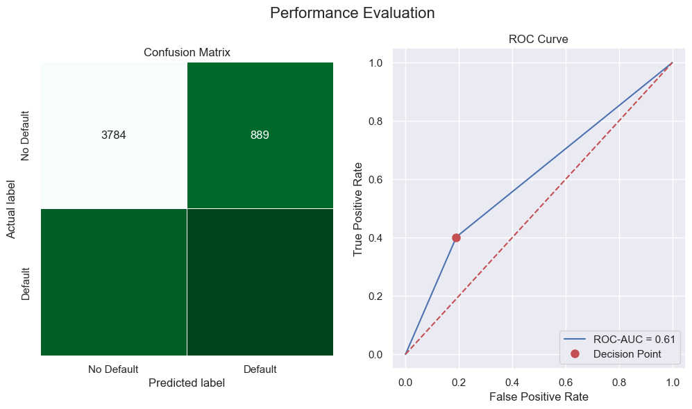

```python
# 결과 평가
LABELS = ['No Default', 'Default']
tree_perf = performance_evaluation_report(tree_classifier,
                                          X_test_ohe,
                                          y_test, labels=LABELS,
                                          show_plot=True)
```

```python
tree_perf
```

```
{'accuracy': 0.7193333333333334,
 'precision': 0.37438423645320196,
 'recall': 0.400904295403165,
 'specificity': 0.8097581853199229,
 'f1_score': 0.38719068413391555,
 'cohens_kappa': 0.20545212086249653,
 'roc_auc': 0.6059202515178426,
 'pr_auc': 0.4542470275794692}
```

**혼동 행렬**은 다음과 같은 구조다.

```
TN | FP
FN | TP
```

**정확도accuarcy ((TP + TN) / (TP + FP + TN + FN))**

- 모델의 전체 능력을 정확하게 예측할 수 있는 능력을 측정

**정밀도precision (TP / (TP + FP))**

- 디폴트라고 예측한 값 중 실제 디폴트인 값의 비율

**재현율recall (TP / (TP + FN))**

- 실제 디폴트 값 중 디폴트라고 맞게 예측한 비율
- 무작위로 데이터를 입력하여 예측했을 때, 결과가 정확히 Positive로 나올 확률이다.
- **민감도** 또는 참 긍정 비율라고도 한다.

**특이성specificity (TN / (TN + FP))**

- 실제 디폴트 하지 않은 고객 중 맞게 예측한 비율
- Recall과 반대 개념으로, Negative를 정확히 예측할 확률이다.

**F-1 점수**

- 정밀도와 재현율의 조화 평균값
- Precision과 Recall의 수치를 고려했을 때, Positive와 Negative 중 어느 것에 예측력이 더 높은지를 알려주는 지표이다.

**ROC곡선**

- 서로 다른 확률 임계값에 대해 참 긍정(TP) 비율과 거짓 긍정 비율(FP) 간의 절충점을 나타낸다.
- 확률 임계값은 예측이 긍정 부류에 속한다고 결정하는 예측 확률을 결정한다.(기본적으로 50%)
- 이상적인 점은 (0,1)이며, 숙련된 모델은 이 값에 가깝다. 그렇지 않은 모델은 대각선(45도)에 가까운 선을 갖는다.

**ROC곡선 아래 영역 AUC**

- 이 값은 0.5 ~ 1 의 값을 가진 지표
- **pr_auc**는 Precision과 Recall curve에 대한 면적

```python
# Graphviz 환경변수 설정
# import os
# os.environ["PATH"] += os.pathsep + 'C:/Program Files/Graphviz/bin/'
```

```python
small_tree = DecisionTreeClassifier(max_depth=3,
                                    random_state=42)
small_tree.fit(X_train_ohe, y_train)

tree_dot = StringIO()
export_graphviz(small_tree, feature_names=X_train_ohe.columns,
                class_names=LABELS, rounded=True, out_file=tree_dot,
                proportion=False, precision=2, filled=True)
tree_graph = pydotplus.graph_from_dot_data(tree_dot.getvalue())
tree_graph.set_dpi(300)
Image(value=tree_graph.create_png())
```

[output not shown]

##### 추가 사항

ROC 곡선은 부류 불균형을 처리할 경우에는 모델의 성능 평가시 신뢰성을 잃어버린다. 예를 들어 99%의 데이터가 사기가 아니며 1%만이 사기인 경우 모든 관측값을 사기가 아닌 경우로 분류하는 단순 모델은 99%의 정확도를 달성하지만 실제로는 가치가 없다. 그렇기 때문에 또 다른 곡선인 정밀도-재현율 곡선을 사용해야 한다. 이는 정밀도 재현율 계산시 참 부정(TN)을 사용하지 않고 소수 부류(긍정 부류)의 정확한 예측만을 고려하기 때문이다.

```python
y_pred_prob = tree_classifier.predict_proba(X_test_ohe)[:, 1]
precision, recall, thresholds = metrics.precision_recall_curve(y_test, y_pred_prob)
```

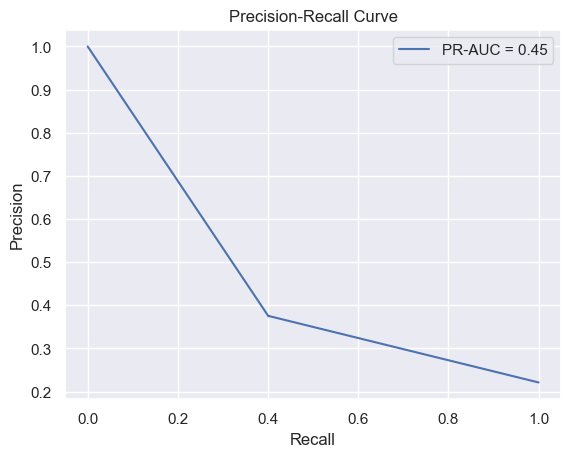

```python
ax = plt.subplot()
ax.plot(recall, precision,
       label = f'PR-AUC = {metrics.auc(recall, precision):.2f}')
ax.set(title = 'Precision-Recall Curve',
       xlabel = 'Recall',
       ylabel = 'Precision')
ax.legend()
```

### scikit-learn의 파이프라인 구현

#### 파이프라인 사용시 이점

- 흐름을 쉽게 읽고 이해할 수 있다. 주어진 열에 대해 실행할 연산의 체인이 명확하다.
- 단계의 순서가 파이프라인에 의해 강제화된다.
- 재현하기가 쉽다.

```python
import pandas as pd
from sklearn.model_selection import train_test_split
from sklearn.impute import SimpleImputer
from sklearn.preprocessing import OneHotEncoder
from sklearn.compose import ColumnTransformer
from sklearn.tree import DecisionTreeClassifier
from sklearn.pipeline import Pipeline
```

```python
df = pd.read_csv('credit_card_default.csv', index_col=0, na_values='')
X = df.copy()
y = X.pop('default_payment_next_month')

X_train, X_test, y_train, y_test = train_test_split(X, y,
                                                   test_size = 0.2,
                                                   stratify = y)
```

```python
num_features = X_train.select_dtypes(include='number').columns.to_list()
cat_features = X_train.select_dtypes(include='object').columns.to_list()
```

```python
# 수치 파이프라인을 정의한다.
num_pipeline = Pipeline(steps=[
    ('imputer', SimpleImputer(strategy='median'))
])
```

```python
# 범주 파이프라인을 정의한다.
cat_list = [list(X_train[col].dropna().unique()) for col in cat_features]

cat_pipeline = Pipeline(steps=[
    ('imputer', SimpleImputer(strategy='most_frequent')),
    ('onehot', OneHotEncoder(categories = cat_list, sparse = False,
                            handle_unknown = 'error', drop = 'first'))
])
```

```python
preprocessor = ColumnTransformer(transformers=[
    ('numerical', num_pipeline, num_features),
    ('categorical', cat_pipeline, cat_features)],
                                 remainder='drop')
```

```python
# 결합 파이프라인을 생성한다.
dec_tree = DecisionTreeClassifier(random_state=42)

tree_pipeline = Pipeline(steps=[('preprocessor', preprocessor),
                               ('classifier', dec_tree)])
```

```python
tree_pipeline.fit(X_train, y_train)
```

```
Pipeline(steps=[('preprocessor',
                 ColumnTransformer(transformers=[('numerical',
                                                  Pipeline(steps=[('imputer',
                                                                   SimpleImputer(strategy='median'))]),
                                                  ['limit_bal', 'age',
                                                   'bill_statement_sep',
                                                   'bill_statement_aug',
                                                   'bill_statement_jul',
                                                   'bill_statement_jun',
                                                   'bill_statement_may',
                                                   'bill_statement_apr',
                                                   'previous_payment_sep',
                                                   'previous_payment_aug',
                                                   'previous_payment_j...
                                                                                              '4 '
                                                                                              'months',
                                                                                              'Payment '
                                                                                              'delayed '
                                                                                              '8 '
                                                                                              'months',
                                                                                              'Payment '
                                                                                              'delayed '
                                                                                              '6 '
                                                                                              'months',
                                                                                              'Payment '
                                                                                              'delayed '
                                                                                              '5 '
                                                                                              'months']],
                                                                                 drop='first',
                                                                                 sparse=False))]),
                                                  ['sex', 'education',
                                                   'marriage',
                                                   'payment_status_sep',
                                                   'payment_status_aug',
                                                   'payment_status_jul',
                                                   'payment_status_jun',
                                                   'payment_status_may',
                                                   'payment_status_apr'])])),
                ('classifier', DecisionTreeClassifier(random_state=42))])
```

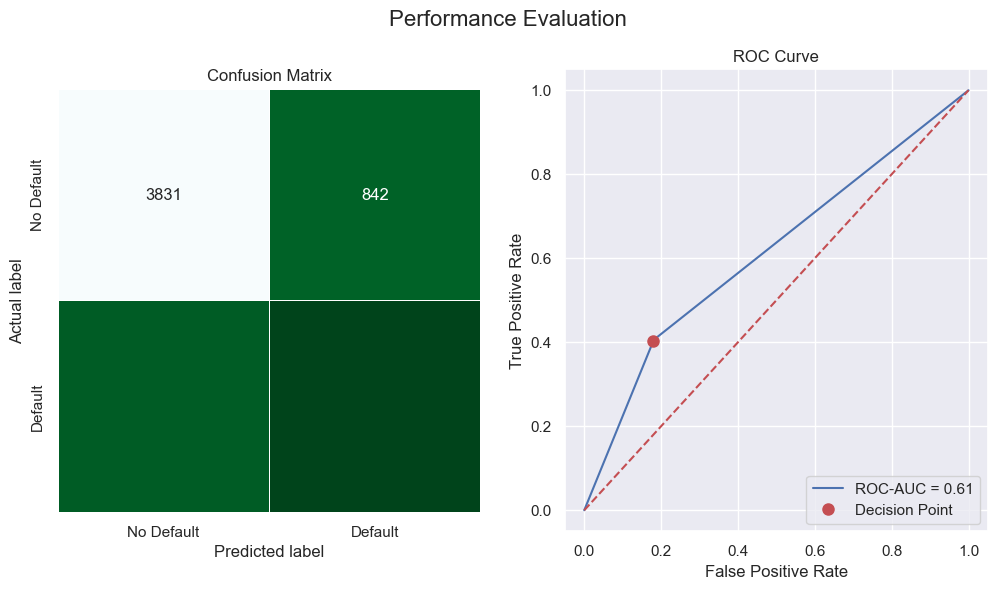

```python
LABELS=['No Default', 'Default']
tree_perf = performance_evaluation_report(tree_pipeline, X_test, y_test, labels=LABELS, show_plot=True)
```

#### 추가 사항

- **수치 변수의 스케일링**: 서로 다른 척도로 측정된 상이한 변수의 범위를 변경하는 것이다. 이것은 모델에 편향을 유발할 수 있다. 특성 간의 거리를 계산하는 모델(예: KNN모델)을 처리할 때 필요하다. 일반적으로 의사결정 트리를 기반으로 하는 방법에는 스케일링이 필요하지 않다.
- **연속변수의 이산화**: 예를 들어 나이를 25이하, 25~50, 50이상으로 변환할 수 있다.
- **이상값 변환/제거**: 이상값은 모형의 결과를 왜곡시킬 수 있으므로 처리하는 것이 좋다. 제거하는 것은 일반화 능력에 영향을 줄 수 있기 때문에 정규값에 가깝게 변환할 수 있다.

```python
from sklearn.base import BaseEstimator, TransformerMixin
```

```python
class OutlierRemover(BaseEstimator, TransformerMixin):
    def __init__(self, n_std=3):
        self.n_std = n_std
    def fit(self, X, y = None):
        if np.isnan(X).any(axis=None):
            raise ValueError('''There are missing values in the array! Please remove them.''')

        mean_vec = np.mean(X, axis=0)
        std_vec = np.std(X, axis=0)
        self.upper_band_ = mean_vec + self.n_std * std_vec
        self.lower_band_ = mean_vec - self.n_std * std_vec
        self.n_features_ = len(self.upper_band_)
        return self
    def transform(self, X, y = None):
        X_copy = pd.DataFrame(X.copy())
        upper_band = np.repeat(
            self.upper_band_.reshape(self.n_features_, -1),
            len(X_copy), axis=1).transpose()
        lower_band = np.repeat(
            self.lower_band_.reshape(self.n_features_, -1),
            len(X_copy), axis=1).transpose()

        X_copy[X_copy >= upper_band] = upper_band
        X_copy[X_copy <= lower_band] = lower_band
        return X_copy.values
```

```python
# 수치 파이프라인에 OutlierRemover를 추가
num_pipeline = Pipeline(steps=[
    ('imputer', SimpleImputer(strategy='median')),
    ('outliers', OutlierRemover())
])
```

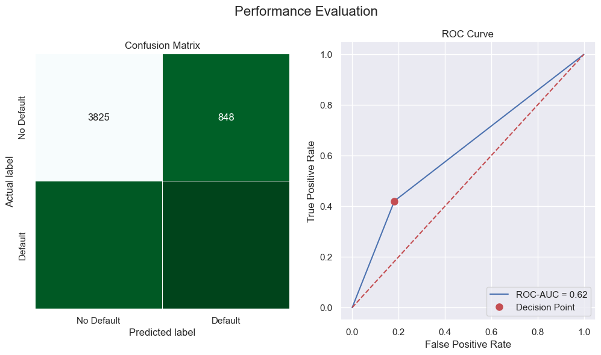

```python
preprocessor = ColumnTransformer(transformers=[
    ('numerical', num_pipeline, num_features),
    ('categorical', cat_pipeline, cat_features)],
                                 remainder='drop')

dec_tree = DecisionTreeClassifier(random_state=42)

tree_pipeline = Pipeline(steps=[('preprocessor', preprocessor),
                               ('classifier', dec_tree)])

tree_pipeline.fit(X_train, y_train)

tree_perf = performance_evaluation_report(tree_pipeline, X_test,
                                         y_test, labels=LABELS,
                                         show_plot=True)
```

이상값을 제한하는 변환을 포함해도 전체 파이프라인의 성능에는 큰 변화가 없다.

### 그리드 검색 및 교차 검증을 사용해 초매개 변수 조정

**초매개 변수**:

- 모델의 외부 특성을 나타낸다.
- 데이터에 기반해 추정되지 않는다.
- 조정을 통해 더 나은 성능을 얻을 수 있다.

**매개 변수**:

- 모델의 내부 속성을 나타낸다.
- 데이터에 의해 추정된다. 예를 들어 선형회귀의 계수가 있다.
- 훈련과정을 통해 학습한다.

검증 집합은 테스트 집합을 사용한 최종 평가 전에 모델의 초매개변수를 명시적으로 조정하는데 사용된다. 그러나 검증 집합을 만들려면 비용이 소요된다. 훈련과 테스트에 사용할 데이터가 줄어드므로 소규모 데이터셋을 처리하는데 특히 안 좋을 수 있다. 그렇기 때문에 **교차 검증**을 사용해 모델의 일반화 오류에 대한 신뢰할 수 있는 추정치를 얻을 수 있다.

```python
from sklearn.model_selection import (GridSearchCV, cross_val_score,
                                     RandomizedSearchCV,
                                     cross_validate,
                                     StratifiedKFold)
```

```python
# 교차 검증을 정의한다.
# 데이터에 고유한 순서(시계열 데이터)가 없으므로 shuffle 사용
k_fold = StratifiedKFold(5, shuffle=True, random_state=42)
```

```python
# 교차 검증을 사용해 파이프라인을 평가한다. 이 결과는 추정기의 정확도를 가진 배열을 생성한다.
cross_val_score(tree_pipeline, X_train, y_train, cv=k_fold)
```

```
array([0.715625  , 0.73125   , 0.73083333, 0.72291667, 0.725     ])
```

```python
# 교차 검증에 척도를 추가한다.
cross_validate(tree_pipeline, X_train, y_train, cv=k_fold, scoring=['accuracy', 'precision', 'recall', 'roc_auc'])
```

```
{'fit_time': array([0.80179477, 0.80193377, 0.82791805, 0.80099273, 0.77939463]),
 'score_time': array([0.05701661, 0.04686499, 0.0480566 , 0.04810071, 0.03371048]),
 'test_accuracy': array([0.715625  , 0.73125   , 0.73083333, 0.72291667, 0.725     ]),
 'test_precision': array([0.37040205, 0.40086957, 0.39876761, 0.38777219, 0.37953488]),
 'test_recall': array([0.40772128, 0.43408663, 0.42655367, 0.43596987, 0.38454288]),
 'test_roc_auc': array([0.60531504, 0.62519006, 0.62176441, 0.62073651, 0.60274726])}
```

**그리드 검색**은 가능한 모든 초매개 변수 조합의 그리드를 생성하고 각각을 사용해 모델을 학습시키는 것이다. 단점은 교차 검증을 사용하는 경우 필요한 모형 적합 및 예측 수가 크게 증가한다. **랜덤 검색**은 무작위 초매개 변수 세트를 선택하고 모델을 학습하고 점수를 반환하며, 사전 정의된 반복 횟수나 계산 시간에 도달할 때까지 전체 프로세스를 반복한다. 매우 큰 그리드를 처리할 때는 그리드 검색보다 랜덤 검색이 선호된다.

파이프라인 작업시 명명 규칙 그리드 딕셔너리 키는 이중 밑줄을 사용해 초매개 변수 이름과 연결된 단계/모델의 이름으로 작성한다.

- criterion: 엔트로피나 지니 중요도의 분할 결정에 사용되는 척도
- max_depth: 트리의 최대 깊이
- min_samples_leaf: 잎에서의 최소 개수. 트리에서 매우 적은 관측값을 가진 잎이 생성되는 것을 막아준다.

```python
# 매개 변수 그리드를 정의한다.
# 교차검증을 사용한 그리드 서치는 시간이 매우 많이 들기 때문에 한번에 모든 범위를 검증하면 안된다.

param_grid = {'classifier__criterion': ['entropy', 'gini'],
             'classifier__max_depth': range(3, 4),
             'classifier__min_samples_leaf': range(2, 3),
             'preprocessor__numerical__outliers__n_std': [3, 4]}
```

```python
classifier_gs = GridSearchCV(tree_pipeline, param_grid, scoring = 'recall', cv=k_fold, n_jobs=-1, verbose=1)
classifier_gs.fit(X_train, y_train)

print(f'Best parameters: {classifier_gs.best_params_}')
print(f'Recall (Training set): {classifier_gs.best_score_:.4f}')
print(f'Recall (Test set): {metrics.recall_score(y_test, classifier_gs.predict(X_test)):.4f}')
```

[output not shown]

```
Fitting 5 folds for each of 4 candidates, totalling 20 fits
```

재현율을 기반으로 가장 우수한 의사결정 트리 모델을 선택하기로 결정했다. 실제로 디폴트였지만 채무 이행으로 예측(FN)와 우량 고객을 디폴트로 예측(FP)의 경우 다른 비용이 발생한다. 디폴트를 놓치는 비율(FN)을 줄이는 대신 더 많이 우량 고객을 디폴트로 예측(FP)하는 비용을 수용하기로 했다.

```python
# 그리드 검색의 성능을 평가한다.
LABELS = ['No Default', 'Default']
tree_gs_perf = performance_evaluation_report(classifier_gs, X_test,
                                            y_test, labels =LABELS,
                                            show_plot=True)
```

[output not shown]

```python
# 랜덤화된 그리드 검색을 실행한다.
classifier_rs = RandomizedSearchCV(tree_pipeline, param_grid,
                                  scoring='recall',
                                  cv=k_fold, n_jobs=-1, verbose=1,
                                  n_iter=100, random_state=42)
print(f'Best parameters: {classifier_rs.best_params_}')
print(f'Recall (Training set): {classifier_rs.best_score_:.4f}')
print(f'Recall (Test set): {metrics.recall_score(y_test, classifier_rs.predict(X_test)):.4f}')
```

[output not shown]

#### 추가사항

여러 분류기를 포함하는 그리드를 만들 수도 있다.

```python
from sklearn.linear_model import LogisticRegression
```

```python
param_grid = [{'classifier': [LogisticRegression()],
              'classifier__penalty': ['l1', 'l2'],
              'classifier__C': np.logspace(0, 3, 10, 2),
              'preprocessor__numerical__outliers__n_std': [3,4]},
             {'classifier': [DecisionTreeClassifier(random_state=42)],
             'classifier__criterion': ['entropy', 'gini'],
             'classifier__max_depth': range(3, 11),
             'classifier__min_samples_leaf': range(2, 11),
             'preprocessor__numerical__outliers__n_std': [3, 4]}]
```

```python
classifier_gs_2 = GridSearchCV(tree_pipeline, param_grid, scoring='recall', cv=k_fold, n_jobs=-1, verbose=1)
classifier_gs_2.fit(X_train, y_train)

print(f'Best parameters: {classifier_gs_2.best_params_}')
print(f'Recall (Training set): {classfier_gs_2.best_score_:.4f}')
print(f'Recall (Test set): {metrics.recall_score(y_test, classifier_gs_2.predict(X_test)):.4f}')
```

[output not shown]